# Final Project

Albert Wang

5/17/2018

## DonorsChoose for Education

#### Data Science for Good Challenge

### Introduction and Motivation

This project is motivated by the Data Science For Good challenge on Kaggle located at https://www.kaggle.com/donorschoose/io. From their introduction:

> Founded in 2000 by a Bronx history teacher, DonorsChoose.org has raised $685 million for America’s classrooms. Teachers at three-quarters of all the public schools in the U.S. have come to DonorsChoose.org to request what their students need, making DonorsChoose.org the leading platform for supporting public education.

> To date, 3 million people and partners have funded 1.1 million DonorsChoose.org projects. But teachers still spend more than a billion dollars of their own money on classroom materials. To get students what they need to learn, the team at DonorsChoose.org needs to be able to connect donors with the projects that most inspire them.

This is especially taxing on teachers with low incomes in less wealthy school districts:

[figure not shown]

Source: Gina Tomko

The goal of this project is to provide a tutorial on how to suggest open projects to past donors. We walk through the entire data science pipeline of “data curation, parsing, and management; exploratory data analysis; hypothesis testing and machine learning to provide analysis; and then the curation of a message or messages covering insights learned during the tutorial”.

### Retrieving the Data

Data was retrived from a direct download from Kaggle at https://www.kaggle.com/donorschoose/io/data.

To convert the `.csv` files into dataframes, we can use the `read_csv` function in `readr`.

```r
donations <- read_csv("io/Donations.csv")
donors <- read_csv("io/Donors.csv")
projects <- read_csv("io/Projects.csv")
resources <- read_csv("io/Resources.csv")
schools <- read_csv("io/Schools.csv")
teachers <- read_csv("io/Teachers.csv")
colnames(donations) <- make.names(colnames(donations), unique=TRUE)
colnames(donors) <- make.names(colnames(donors), unique=TRUE)
colnames(projects) <- make.names(colnames(projects), unique=TRUE)
colnames(schools) <- make.names(colnames(schools), unique=TRUE)
colnames(teachers) <- make.names(colnames(teachers), unique=TRUE)
```

### Exploratory Data Analysis

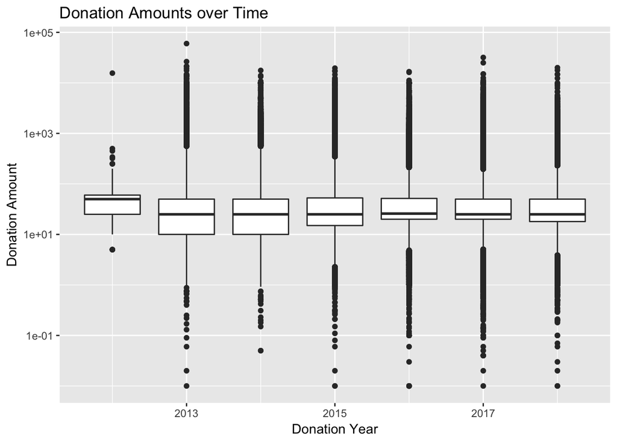

```r
donations <- donations %>%
  mutate(Year.ID = year(Donation.Received.Date))

donations %>%
  ggplot(aes(x=Year.ID, y=Donation.Amount, group=Year.ID)) +
    scale_y_log10("Donation Amount") +
    geom_boxplot() +
    labs(title="Donation Amounts over Time",
          x = "Donation Year",
          y = "Donation Amount (Dollars)")
```

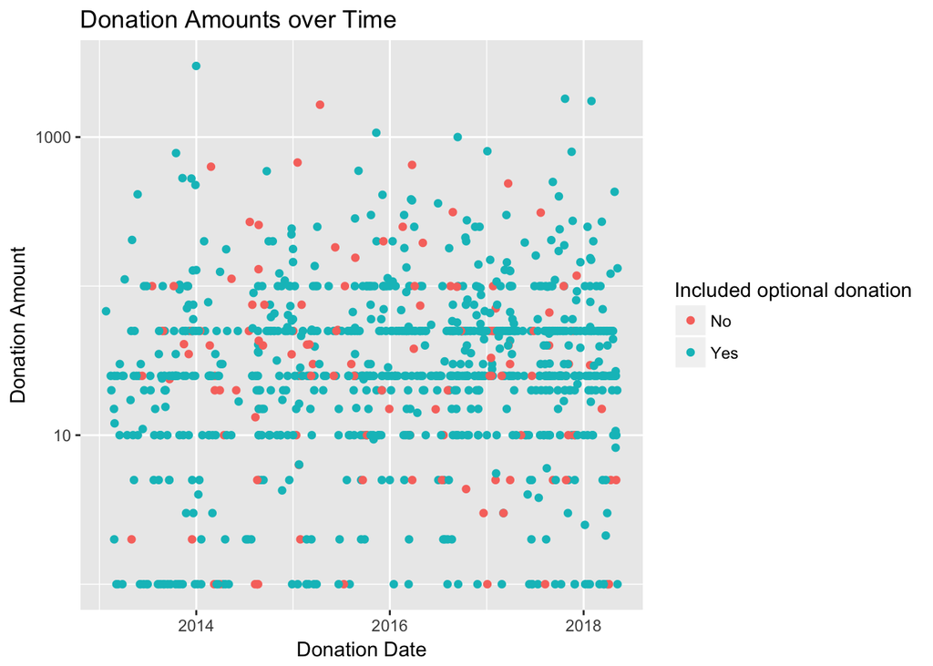

```r
donations %>%
 sample_n(1000) %>%
  ggplot(aes(x=Donation.Received.Date, y=Donation.Amount, color=Donation.Included.Optional.Donation)) +
    scale_y_log10("Donation Amount") +
    geom_point() +
    labs(title="Donation Amounts over Time",
          x = "Donation Date",
          y = "Donation Amount (Dollars)",
          color = "Included optional donation")
```